# Random Walk

Conner Shoop, Ryan Faris

10/15/2017

## Random Walk

This is a function random_walk

```r
random_walk <- function(steps,seed,probs){

  #intilialize matrix
  walk <- matrix(0,steps+1,3)
  walk[1,] <- c(0,0,0)

  #set random seed
  set.seed(seed)

  #set probabilities
  p <- probs

  for(i in 1:steps){
    rn <- runif(1)
    if (rn < p[1]) {walk[i+1,] <- walk[i,] + c(1,0,0)}
    if (rn>=p[1] && rn<p[2]) {walk[i+1,] <- walk[i,] + c(-1,0,0)}
    if (rn>=p[2] && rn<p[3]) {walk[i+1,] <- walk[i,] + c(0,1,0)}
    if (rn>=p[3] && rn<p[4]) {walk[i+1,] <- walk[i,] + c(0,-1,0)}
    if (rn>=p[4] && rn<p[5]) {walk[i+1,] <- walk[i,] + c(0,0,1)}
    if (rn >= p[5]) {walk[i+1,] <- walk[i,] + c(0,0,-1)}
  }
return(walk)
}
```

The function takes arguments steps, seed, and the vector of “probabilities”, i.e $[a1,a2,a3,a4,a5]$, and returns an nx3 matrix with n being the number of steps+1 (to account for the initial position). Steps is the number of steps for our function to make in the xyz plane, and seed is the seed for random number generation.

## Part A

We will plot a 3D random walk with $B=10^4$, $a_i=\frac i6$, and seed 1982.

```r
library(plot3D)
B <- 10^4
seed <- 1982
probabilities <- (c(1:5))/6
walk <- random_walk(B,seed,probabilities)
walk[B+1,]
```

```
## [1]  26 -44  26
```

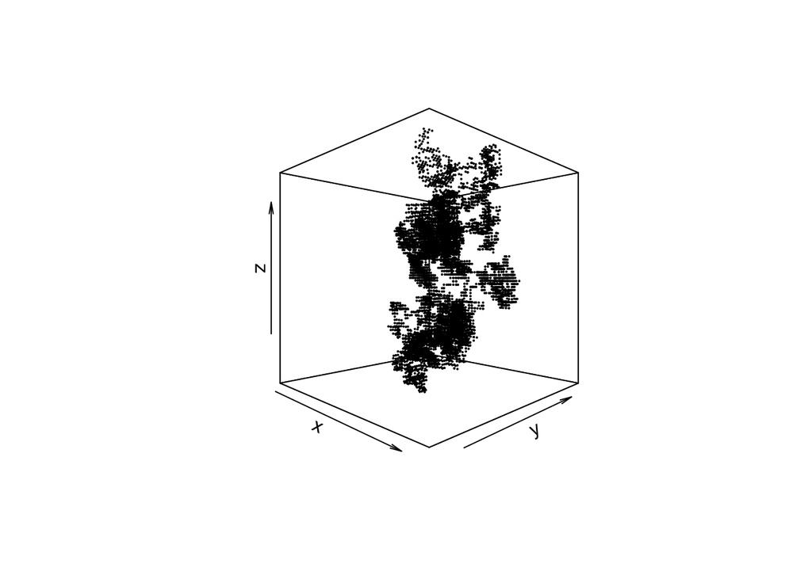

```r
segments3D(walk[,1], walk[,2], walk[,3], lwd=2, theta = 45, phi=0)
```

## Part B

We will plot a 3D random walk with $B=10^5$, $a_i=0.99\frac i6$, and seed 2000.

```r
library(plot3D)
B <- 10^5
seed <- 2000
probabilities <- .99*(c(1:5))/6
walk <- random_walk(B,seed,probabilities)
walk[B+1,]
```

```
## [1]  142 -133 -899
```

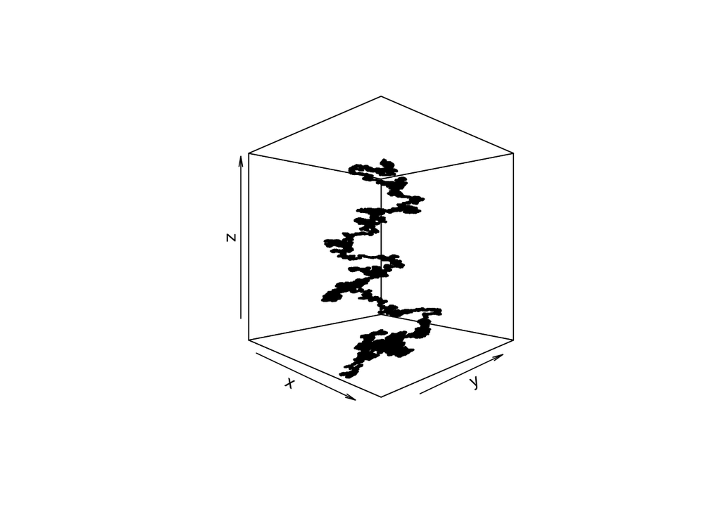

```r
segments3D(walk[,1], walk[,2], walk[,3], lwd=2, theta = 45, phi=0)
```

## Part C

Consider the setting in part b.) where $U_t \stackrel{iid}{\sim}\mathcal{U}(0,1)$, $a_i = \frac{.99}{6}i$, and $\mathbf{X}_t = \mathbf{X}_{t - 1} + \mathbf{f}(U_t)$, we will show that $\mathbb{E} \left[ X_B \right] = \left[\begin{matrix}0\\0\\-0.01 B\\\end{matrix}\right]$

We know that
$$\mathbb{E}[\mathbf{X}_B] = \mathbb{E}[\mathbf{X}_{B-1} + \mathbf{f}(U_t)]$$
$$\mathbb{E}[\mathbf{X}_{B-1}] = \mathbb{E}[\mathbf{X}_{B-2} + \mathbf{f}(U_{t-1})]$$

Because of the linearity of expectation

$$\implies \mathbb{E}[\mathbf{X}_B] = \mathbb{E}[\mathbf{X}_{B-1}] + \mathbb{E}[\mathbf{f}(U_B)]$$
$$\implies \mathbb{E}[\mathbf{X}_B] = \mathbb{E}[\mathbf{X}_{B-2}] + \mathbb{E}[\mathbf{f}(U_{B})] + \mathbb{E}[\mathbf{f}(U_{B-1})]$$

Since ${U_t}$ and ${U_{t-1}}$ are identically distributed, in general $\mathbb{E}[\mathbf{f}(U_{t})]$ = $\mathbb{E}[\mathbf{f}(U_{t-1})]$

$$\implies \mathbb{E}[\mathbf{X}_B] = \mathbb{E}[\mathbf{X}_{B-2}] + 2\mathbb{E}[\mathbf{f}(U_{t})]$$
$$\implies \mathbb{E}[\mathbf{X}_B] = \mathbb{E}[\mathbf{X}_{0}] + B\mathbb{E}[\mathbf{f}(U_{t})]$$
$$\implies \mathbb{E}[\mathbf{X}_B] = \left[\begin{matrix}0\\0\\0\\\end{matrix}\right] + B\mathbb{E}[\mathbf{f}(U_{t})]$$
$$\implies \mathbb{E}[\mathbf{X}_B] = B\mathbb{E}[\mathbf{f}(U_{t})]$$
Now we just have to figure out $\mathbb{E}[\mathbf{f}(U_{t})]$

$$\mathbb{E}[\mathbf{f}(U_{t})] = \left[\begin{matrix}1\\0\\0\\\end{matrix}\right] * \Pr(U_t \leq a_{1}) + \left[\begin{matrix}-1\\0\\0\\\end{matrix}\right]*\Pr(a_1 \leq U_t \leq a_{2})
+ \left[\begin{matrix}0\\1\\0\\\end{matrix}\right]*\Pr(a_2 \leq U_t \leq a_{3})
+ ... + \left[\begin{matrix}0\\0\\-1\\\end{matrix}\right] * \Pr(U_t \geq a_5)$$

For $i = [1,2,...,4],$ $\Pr(a_i \leq U_t \leq a_{i+1}) = a_{i+1} - a_i = \frac{.99}{6}(i+1) - \frac{.99}{6}i = \frac{.99}{6}$

and also, $\Pr(U_t \leq a_1) = \frac{.99}{6}$ and $\Pr(U_t\geq a_5) = 1 - 5(\frac{.99}{6})$

$$\implies \mathbb{E}[\mathbf{f}(U_{t})] = (\left[\begin{matrix}1\\0\\0\\\end{matrix}\right] + \left[\begin{matrix}-1\\0\\0\\\end{matrix}\right]
+ \left[\begin{matrix}0\\1\\0\\\end{matrix}\right]
+ \left[\begin{matrix}0\\-1\\0\\\end{matrix}\right]
+ \left[\begin{matrix}0\\0\\1\\\end{matrix}\right])*(\frac{.99}{6})
+ \left[\begin{matrix}0\\0\\-1\\\end{matrix}\right]*( 1 - 5(\frac{.99}{6}))$$

$$\implies \mathbb{E}[\mathbf{f}(U_{t})] = \left[\begin{matrix}0\\0\\1\\\end{matrix}\right]*(\frac{.99}{6})
+ \left[\begin{matrix}0\\0\\-1\\\end{matrix}\right]* (1 - 5(\frac{.99}{6}))$$

$$\implies \mathbb{E}[\mathbf{f}(U_{t})] = \left[\begin{matrix}0\\0\\-1\\\end{matrix}\right]*0.01$$
Because $\mathbb{E}[\mathbf{X}_B] = B\mathbb{E}[\mathbf{f}(U_{t})]$

$$\implies \mathbb{E}[\mathbf{X}_B] = B*\left[\begin{matrix}0\\0\\-1\\\end{matrix}\right]*0.01 = \left[\begin{matrix}0\\0\\-0.01B\\\end{matrix}\right]$$

## Part 4

Now, after trying many different methods to animate a random walk, mostly in plotly, I ended up using the most basic approach. I simply plotted the random walk, step by step, taking pictures of each plot as a PNG.

```r
frames = B+1
for(i in 2:frames){
  #make names
  if (i < 10) {name = paste('000',i,'plot.png',sep='')}
  if (i < 100 && i >= 10) {name = paste('00',i,'plot.png', sep='')}
  if (i >= 100 && i <1000) {name = paste('0', i,'plot.png', sep='')}
  if (i >= 1000) {name = paste('0', i,'plot.png', sep='')}
}
  #saves the plot as a .png file in the working directory
  png(name)
  segments3D(x0=walk[1:i-1,1], y0=walk[1:i-1,2], z0=walk[1:i-1,3],
             x1=walk[2:i,1], y1=walk[2:i,2], z1=walk[2:i,3], phi=0, theta=45)
  dev.off()
```

Then I utilized a free web service gifmaker.me, to animate my images for me. Unfortunately it could only do the first 200 images. Then I had to convert it to mp4, I used ezgif.com, another free web service. I would embed the result, but I cannot figure it out. The file is randomWalk200.mp4, in this folder.